# Wine Quality Logistic Regression

Jim Harner

7/25/2018

## 7.5 Wine Quality Logistic Regression

This section explores feature selection based on regularization.

### 7.5.1 Regularized Logistic Regression with Spark

We now revisit the Wine Quality Data Set analyzed in Section 7.3.1. Our goal is to continue with advanced analyses.

We read the `winequality-red.csv` file into a Spark DataFrame using `spark_red_csv`. We want to ensure the training and test data frames are identical to those in Section 7.3.1.

```r
wine_red_sdf <- spark_read_csv(sc, "wine_red_sdf",
    path = "file:///home/rstudio/rspark-tutorial/data/wine/winequality-red.csv",
    delimiter = ";" )
wine_red_tbl <- sdf_register(wine_red_sdf, name = "wine_red_tbl")
```

We split `wine_red_sdf` into a training and a test Spark DataFrame as before and cast `quality` as numeric in order to binarize it with a threshold.

```r
wine_red_partition <- wine_red_tbl %>%
  mutate(quality = as.numeric(quality)) %>%
  ft_binarizer(input.col = "quality", output.col = "quality_bin",
               threshold = 5.0) %>%
  sdf_partition(training = 0.7, test = 0.3, seed = 2)
wine_red_train_sdf <- wine_red_partition$training
wine_red_test_sdf <- wine_red_partition$test
```

The full model is now run.

```r
wine_red_br_full_fit <- wine_red_train_sdf %>%
  ml_logistic_regression(quality_bin ~ fixed_acidity + volatile_acidity
                         + citric_acid + residual_sugar + chlorides
                         + free_sulfur_dioxide + total_sulfur_dioxide
                         + density + pH + sulphates + alcohol)
summary(wine_red_br_full_fit)
```

```
## Coefficients:
##          (Intercept)        fixed_acidity     volatile_acidity
##          -0.10386892          -0.10923873           3.10282061
##          citric_acid       residual_sugar            chlorides
##           1.16370571          -0.03658113           3.76465773
##  free_sulfur_dioxide total_sulfur_dioxide              density
##          -0.02951821           0.01834968           7.82354054
##                   pH            sulphates              alcohol
##           0.55299156          -2.70425681          -0.91995058
```

```r
wine_red_br_fnc <- function(l) {
  wine_red_train_sdf %>%
    ml_logistic_regression(quality_bin ~ fixed_acidity + volatile_acidity
                           + citric_acid + residual_sugar + chlorides
                           + free_sulfur_dioxide + total_sulfur_dioxide
                           + density + pH + sulphates + alcohol,
                           elastic_net_param = 1, reg_param = l)
}
```

```r
regParm <- c(0.0, 0.05, 0.1, 0.15, 0.2, 0.25, 0.3, 0.35, 0.4)
wine_red_br_auc <- data.frame(lambda = 0,
                              auc = wine_red_br_full_fit$summary$area_under_roc)
wine_red_br_coef <- as.data.frame(wine_red_br_full_fit$coefficients)
```

We now calculate the `coefficients` and `auc` for each of the models.

```r
for(l in regParm) {
  wine_red_br_fit <- wine_red_br_fnc(l)
  wine_red_br_auc <- data.frame(lambda = l,
                        auc = wine_red_br_fit$summary$area_under_roc) %>%
    rbind(wine_red_br_auc, .)
  wine_red_br_coef <-
    as.data.frame(wine_red_br_fit$coefficients) %>%
    cbind(wine_red_br_coef, .)
}
wine_red_br_auc
```

```
##    lambda       auc
## 1    0.00 0.8186096
## 2    0.00 0.8186096
## 3    0.05 0.8039038
## 4    0.10 0.7869710
## 5    0.15 0.7501001
## 6    0.20 0.7500733
## 7    0.25 0.5000000
## 8    0.30 0.5000000
## 9    0.35 0.5000000
## 10   0.40 0.5000000
```

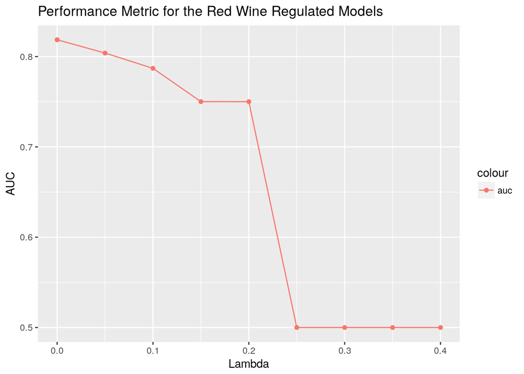

```r
library(ggplot2)
wine_red_br_auc %>%
  ggplot(aes(x = lambda)) +
  geom_point(aes(y = auc, color = 'auc')) +
  geom_line(aes(y = auc, color = 'auc')) +
  ggtitle("Performance Metric for the Red Wine Regulated Models") +
  xlab("Lambda") + ylab("AUC")
```

```r
names(wine_red_br_coef) <- as.character(rbind(c(0.0, regParm)))
wine_red_br_coef <- t(wine_red_br_coef)
wine_red_br_coef
```

```
##      (Intercept) fixed_acidity volatile_acidity citric_acid residual_sugar
## 0     -0.1038689  -0.109238731        3.1028206   1.1637057    -0.03658113
## 0     -0.1038689  -0.109238731        3.1028206   1.1637057    -0.03658113
## 0.05  -0.1029188  -0.006334913        2.0322000  -0.1432685     0.00000000
## 0.1   -0.1029142   0.000000000        0.8434967   0.0000000     0.00000000
## 0.15  -0.1018003   0.000000000        0.0000000   0.0000000     0.00000000
## 0.2    2.4034147   0.000000000        0.0000000   0.0000000     0.00000000
## 0.25  -0.1029277   0.000000000        0.0000000   0.0000000     0.00000000
## 0.3   -0.1029277   0.000000000        0.0000000   0.0000000     0.00000000
## 0.35  -0.1029277   0.000000000        0.0000000   0.0000000     0.00000000
## 0.4   -0.1029277   0.000000000        0.0000000   0.0000000     0.00000000
##      chlorides free_sulfur_dioxide total_sulfur_dioxide   density
## 0     3.764658         -0.02951821          0.018349679 7.8235405
## 0     3.764658         -0.02951821          0.018349679 7.8235405
## 0.05  0.000000          0.00000000          0.004781611 4.8010143
## 0.1   0.000000          0.00000000          0.000000000 3.5460383
## 0.15  0.000000          0.00000000          0.000000000 2.5337397
## 0.2   0.000000          0.00000000          0.000000000 0.7791833
## 0.25  0.000000          0.00000000          0.000000000 0.0000000
## 0.3   0.000000          0.00000000          0.000000000 0.0000000
## 0.35  0.000000          0.00000000          0.000000000 0.0000000
## 0.4   0.000000          0.00000000          0.000000000 0.0000000
##                pH  sulphates    alcohol
## 0    0.5529915563 -2.7042568 -0.9199506
## 0    0.5529915563 -2.7042568 -0.9199506
## 0.05 0.0001675281 -0.4208536 -0.5500804
## 0.1  0.0000000000  0.0000000 -0.3827777
## 0.15 0.0000000000  0.0000000 -0.2430855
## 0.2  0.0000000000  0.0000000 -0.3200588
## 0.25 0.0000000000  0.0000000  0.0000000
## 0.3  0.0000000000  0.0000000  0.0000000
## 0.35 0.0000000000  0.0000000  0.0000000
## 0.4  0.0000000000  0.0000000  0.0000000
```

The interpretation is better if we visualize the coefficient traces.

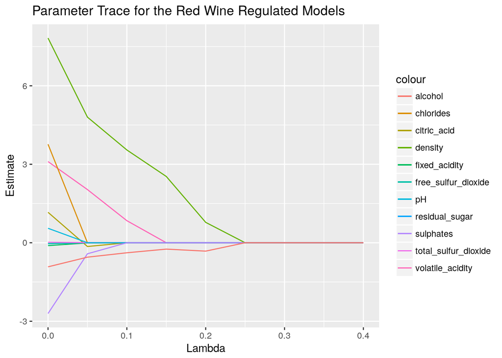

```r
library(ggplot2)
as.data.frame(cbind(lambda = c(0.0, regParm), wine_red_br_coef)) %>%
  ggplot(aes(x = lambda)) +
  geom_line(aes(y = fixed_acidity, color = 'fixed_acidity')) +
  geom_line(aes(y = volatile_acidity, color = 'volatile_acidity')) +
  geom_line(aes(y = citric_acid, color = 'citric_acid')) +
  geom_line(aes(y = residual_sugar, color = 'residual_sugar')) +
  geom_line(aes(y = chlorides, color = 'chlorides')) +
  geom_line(aes(y = free_sulfur_dioxide, color = 'free_sulfur_dioxide')) +
  geom_line(aes(y = total_sulfur_dioxide, color = 'total_sulfur_dioxide')) +
  geom_line(aes(y = density, color = 'density')) +
  geom_line(aes(y = pH, color = 'pH')) +
  geom_line(aes(y = sulphates, color = 'sulphates')) +
  geom_line(aes(y = alcohol, color = 'alcohol')) +
  ggtitle("Parameter Trace for the Red Wine Regulated Models") +
  xlab("Lambda") + ylab("Estimate")
```

The coefficients go to 0 very quickly. Based on regularization, `alcohol` and `density` are still standing at $\lambda = 0.2$, but then they too go to 0. Based on feature importance, `alcohol`, was instead most important.

We now `collect` the training and test Spark DataFrames into R as regular data frames. If you experiment with `alpha` and `lambda`,i.e., invoke the elastic net, you will see the coefficients that are driven to 0 vary greatly.

```r
wine_red_train_df <- collect(wine_red_partition$training)
wine_red_test_df <- collect(wine_red_partition$test)
```

### 7.5.2 Regularized Logistic Regression with glmnet

We can now use `glmnet` to model the wine quality.

```r
wine_red.x <- model.matrix(as.factor(quality_bin) ~ fixed_acidity
                           + volatile_acidity + citric_acid + residual_sugar
                           + chlorides + free_sulfur_dioxide
                           + total_sulfur_dioxide + density + pH + sulphates
                           + alcohol,
                           data = wine_red_train_df)[, -1]
wine_red.y <- wine_red_train_df$quality_bin

wine_red_bin <- glmnet(x = wine_red.x, y = wine_red.y, family = "binomial",
                       alpha = 1, lambda = c(0.0, 0.05, 0.1, 0.15, 0.2, 0.25, 0.3, 0.35, 0.4),
                       standardize = TRUE)
coef(wine_red_bin, s = c(0.0, 0.05, 0.1, 0.15, 0.2, 0.25, 0.3, 0.35, 0.4))
```

```
## 12 x 9 sparse Matrix of class "dgCMatrix"
##                                  1            2          3          4
## (Intercept)           74.757333746 -5.844010852 -4.1092098 -2.5414788
## fixed_acidity          0.214653313  .            .          .
## volatile_acidity      -3.355637998 -1.762840484 -0.8015376  .
## citric_acid           -1.472263078  .            .          .
## residual_sugar         0.068535001  .            .          .
## chlorides             -2.891671705  .            .          .
## free_sulfur_dioxide    0.026636291  .            .          .
## total_sulfur_dioxide  -0.017697980 -0.004566334  .          .
## density              -84.379561425  .            .          .
## pH                    -0.005033606  .            .          .
## sulphates              2.651073108  0.719790932  .          .
## alcohol                0.830848216  0.638758858  0.4466272  0.2543576
##                                5         6         7         8         9
## (Intercept)          -0.49113816 0.1029277 0.1029277 0.1029277 0.1029277
## fixed_acidity         .          .         .         .         .
## volatile_acidity      .          .         .         .         .
## citric_acid           .          .         .         .         .
## residual_sugar        .          .         .         .         .
## chlorides             .          .         .         .         .
## free_sulfur_dioxide   .          .         .         .         .
## total_sulfur_dioxide  .          .         .         .         .
## density               .          .         .         .         .
## pH                    .          .         .         .         .
## sulphates             .          .         .         .         .
## alcohol               0.05708543 .         .         .         .
```

You can experiment with different values of `alpha` and `lambda`.

```r
spark_disconnect(sc)
```